# AutoData_CaseStudy

You need `auto_data.dta`, `variable_descriptions.docx`, and `HorizontalMergers.pdf`.

1. **Written pdf Report.** You're working as a management consulting and your firm has been hired by Volkswagen. VW is interested in growing its presence in the Spanish automobile market. Your firm has acquired data (ie, `auto_data.dta`) to facilitate a market analysis in order to provide a recommendation. Your job is to complete the analysis and draft a report which succinctly describes the market and provides your recommendation. The report should be organized in the following sections:
- **Executive Summary** -- Provide a brief overview of the project, your recommendation, and expected outcome. Think of this as a very high level overview. It should be so clear and concise that your parents could read it and (roughly) understand what you've done and what you're recommending.
- **Market Analysis** -- Describe market trends. I ask you to include some but you're free to discuss others. Be creative and curious but also be careful to only include material which contributes to the overall message.
- **Demand Estimation** -- Describe the model, its usefulness towards developing a recommendation, and the economics underlying your results.
- **Competitive Analysis** -- Describe competition in this market. VW management is particularly interested in understanding how its margins compare to the competition.

# Exploratory Data Analysis

The file "auto_data.dta" contains data on the new car sales of automakers in the Spanish automobile industry from 2009 to 2015. The file "variable_descriptions.docx" describes the variables.

Define product $j$ (industry) market share in each period $t$ year market as

$$ s^{ind}_{jt} = \frac{q_{jt}}{\sum_{k=1}^Jq_{kt}} $$

```
and define $s_t^f$ as total market share of ownership firm $f$ as the sum of all product (industry) market shares $s^{ind}_{jt}$ in its portfiolo. For example, $s_t^\text{VW}$ would be the sum of market shares for behicles branded as Audi, VW, etc. Define the Herfindahl-Hirschman Index (HHI) as
```

$$ \text{HHI}_{t} = \sum_{i=1}^F \big(100 s^f_{t}\big)^2 $$

```
where $F$ is the total number of firms in the industry. The HHI is used as a descriptive statistic for market competition -- an increase in the HHI indicates higher industry concentration (ie, a select number of firms have significant market power). Construct the HHI for each year.
```

```python
import pandas as pd
import matplotlib.pyplot as plt
import seaborn as sns
import statsmodels.formula.api as smf
import linearmodels.iv as iv
```

```python
auto = pd.read_stata('auto_data.dta')
```

```python
auto['Revenue'] = auto['Quantity']*auto['Price']
```

```python
auto[['Quantity','Price','CO2','Weight','CC','HP','Revenue']].describe()
```

|  | Quantity | Price | CO2 | Weight | CC | HP | Revenue |
| --- | --- | --- | --- | --- | --- | --- | --- |
| count | 2810.000000 | 2810.000000 | 2810.000000 | 2810.000000 | 2810.000000 | 2810.000000 | 2810.000000 |
| mean | 1980.273665 | 2.826167 | 152.116837 | 1434.574026 | 1853.032136 | 141.369395 | 4562.459181 |
| std | 3447.504869 | 1.370128 | 43.266684 | 318.035928 | 602.744561 | 57.190212 | 7795.971920 |
| min | 1.000000 | 0.581234 | 37.000000 | 753.213167 | 798.999998 | 45.000000 | 1.172472 |
| 25% | 104.000000 | 1.823695 | 120.246786 | 1210.028282 | 1461.000023 | 103.171602 | 254.862875 |
| 50% | 520.500000 | 2.533465 | 144.425445 | 1411.962966 | 1723.079684 | 132.651924 | 1258.817005 |
| 75% | 2305.750000 | 3.479953 | 171.083923 | 1610.599224 | 2024.272912 | 163.979008 | 5218.270195 |
| max | 28614.000000 | 9.415248 | 373.450001 | 2583.000022 | 5749.400000 | 484.285719 | 69027.028727 |

```python
auto[['Quantity','Price','CO2','Weight','CC','HP','Revenue']].corr()
```

|  | Quantity | Price | CO2 | Weight | CC | HP | Revenue |
| --- | --- | --- | --- | --- | --- | --- | --- |
| Quantity | 1.000000 | -0.219009 | -0.318461 | -0.177292 | -0.206681 | -0.265653 | 0.951655 |
| Price | -0.219009 | 1.000000 | 0.633456 | 0.840724 | 0.848670 | 0.924827 | -0.092045 |
| CO2 | -0.318461 | 0.633456 | 1.000000 | 0.697953 | 0.797435 | 0.671333 | -0.267964 |
| Weight | -0.177292 | 0.840724 | 0.697953 | 1.000000 | 0.818240 | 0.778277 | -0.044761 |
| CC | -0.206681 | 0.848670 | 0.797435 | 0.818240 | 1.000000 | 0.867030 | -0.109383 |
| HP | -0.265653 | 0.924827 | 0.671333 | 0.778277 | 0.867030 | 1.000000 | -0.168545 |
| Revenue | 0.951655 | -0.092045 | -0.267964 | -0.044761 | -0.109383 | -0.168545 | 1.000000 |

```python
auto[['Quantity','Price','CO2','Weight','CC','HP','Revenue']].cov()
```

|  | Quantity | Price | CO2 | Weight | CC | HP | Revenue |
| --- | --- | --- | --- | --- | --- | --- | --- |
| Quantity | 1.188529e+07 | -1034.493737 | -47502.257351 | -194388.205367 | -429475.619876 | -52377.071319 | 2.557730e+07 |
| Price | -1.034494e+03 | 1.877250 | 37.551815 | 366.345180 | 700.863354 | 72.467515 | -9.831785e+02 |
| CO2 | -4.750226e+04 | 37.551815 | 1872.005985 | 9604.091009 | 20796.106558 | 1661.166133 | -9.038571e+04 |
| Weight | -1.943882e+05 | 366.345180 | 9604.091009 | 101146.851410 | 156852.060567 | 14155.731973 | -1.109797e+05 |
| CC | -4.294756e+05 | 700.863354 | 20796.106558 | 156852.060567 | 363301.005311 | 29887.472691 | -5.139883e+05 |
| HP | -5.237707e+04 | 72.467515 | 1661.166133 | 14155.731973 | 29887.472691 | 3270.720370 | -7.514621e+04 |
| Revenue | 2.557730e+07 | -983.178548 | -90385.711088 | -110979.723600 | -513988.314157 | -75146.206878 | 6.077718e+07 |

```python
#auto_quantity = auto.groupby(['Year','Owner']).agg({'Quantity': 'sum'})
auto_quantity = auto.groupby('Year').agg({'Quantity': 'sum'})
auto_quantity.head(20)
```

| Year | Quantity |
| --- | --- |
| 2009 | 889535.000000 |
| 2010 | 912138.000000 |
| 2011 | 738852.000000 |
| 2012 | 641361.999939 |
| 2013 | 663925.000000 |
| 2014 | 779567.000061 |
| 2015 | 939190.000000 |

```python
#auto_revenue = auto.groupby(['Year','Owner']).agg({'Revenue': 'sum'})
auto_revenue = auto.groupby('Year').agg({'Revenue': 'sum'})
auto_revenue.head(20)
```

| Year | Revenue |
| --- | --- |
| 2009 | 2.052088e+06 |
| 2010 | 2.120151e+06 |
| 2011 | 1.722295e+06 |
| 2012 | 1.447619e+06 |
| 2013 | 1.504404e+06 |
| 2014 | 1.785844e+06 |
| 2015 | 2.188110e+06 |

```python
df2 = auto[["Year","Quantity","Owner"]]
firm_rev = df2.groupby(["Year","Owner"]).sum()
m_rev = df2.groupby(["Year"])["Quantity"].sum()
firm_rev = firm_rev.reset_index()
m_size = m_rev.reset_index()
m_size.rename(columns={'Year': 'Year', 'Quantity': 'm_quantity'}, inplace=True)
m_data = pd.merge(firm_rev, m_size, on='Year', how='outer')
m_data['m_share'] = pd.Series((m_data["Quantity"]/m_data["m_quantity"])*100, index=m_data.index)
m_data['sq_m_share'] = pd.Series(m_data["m_share"]*m_data["m_share"], index=m_data.index)
hhi_range = m_data.groupby("Year")["sq_m_share"].sum()
hhi_df = pd.DataFrame(hhi_range)
hhi_df.columns = ['HHI']
hhi_df
```

| Year | HHI |
| --- | --- |
| 2009 | 1308.303191 |
| 2010 | 1283.645549 |
| 2011 | 1280.006458 |
| 2012 | 1254.560532 |
| 2013 | 1216.570175 |
| 2014 | 1179.796977 |
| 2015 | 1142.445819 |

```python
import numpy as np
def y_fmt(y, pos):
    decades = [1e9, 1e6, 1e3, 1e0, 1e-3, 1e-6, 1e-9 ]
    suffix  = ["G", "M", "k", "" , "m" , "u", "n"  ]
    if y == 0:
        return str(0)
    for i, d in enumerate(decades):
        if np.abs(y) >=d:
            val = y/float(d)
            signf = len(str(val).split(".")[1])
            if signf == 0:
                return '{val:d} {suffix}'.format(val=int(val), suffix=suffix[i])
            else:
                if signf == 1:
                    if str(val).split(".")[1] == "0":
                       return '{val:d} {suffix}'.format(val=int(round(val)), suffix=suffix[i])
                tx = "{"+"val:.{signf}f".format(signf = signf) +"} {suffix}"
                return tx.format(val=val, suffix=suffix[i])

    return y
```

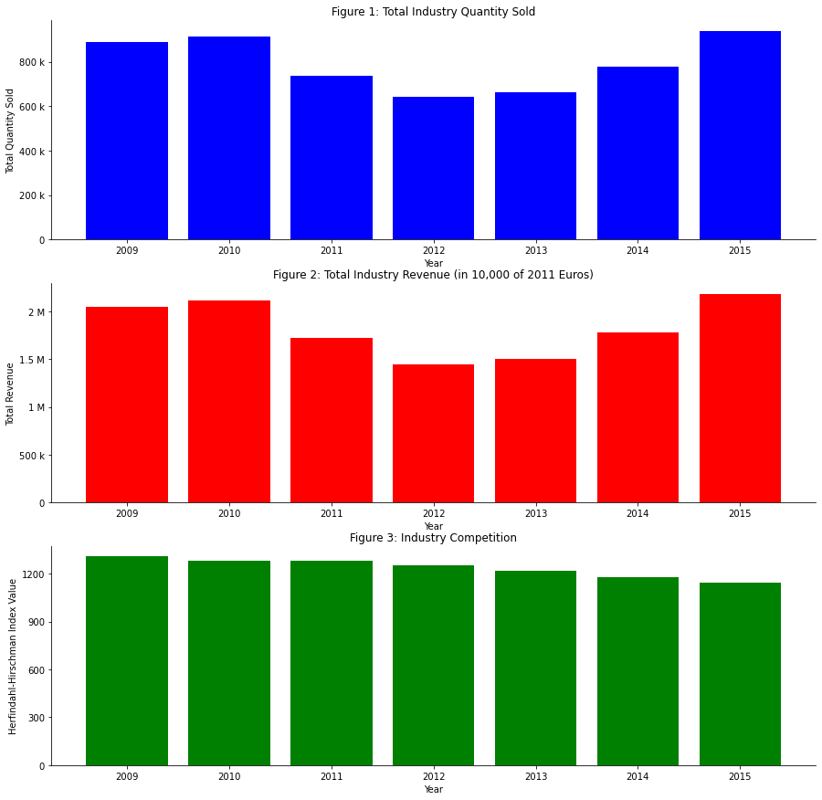

```python
from matplotlib.ticker import FuncFormatter
fig, ax = plt.subplots(3, figsize=(15,15))
ax[0].bar(auto_quantity.index,auto_quantity['Quantity'], label = 'Quantity Sold', color = 'blue')
ax[0].set_xlabel('Year')
ax[0].set_ylabel('Total Quantity Sold')
ax[0].set_title('Figure 1: Total Industry Quantity Sold')
ax[0].spines['right'].set_visible(False)
ax[0].spines['top'].set_visible(False)
ax[0].yaxis.set_major_formatter(FuncFormatter(y_fmt))

ax[1].bar(auto_revenue.index,auto_revenue['Revenue'], label = 'Revenue', color = 'red')
ax[1].set_xlabel('Year')
ax[1].set_ylabel('Total Revenue')
ax[1].set_title('Figure 2: Total Industry Revenue (in 10,000 of 2011 Euros)')
ax[1].spines['right'].set_visible(False)
ax[1].spines['top'].set_visible(False)
ax[1].yaxis.set_major_formatter(FuncFormatter(y_fmt))

ax[2].bar(hhi_df.index,hhi_df['HHI'], label = 'HHI', color = 'green')
ax[2].set_xlabel('Year')
ax[2].set_ylabel('Herfindahl-Hirschman Index Value')
ax[2].set_title('Figure 3: Industry Competition')
ax[2].spines['right'].set_visible(False)
ax[2].spines['top'].set_visible(False)
import matplotlib.ticker as plticker
loc = plticker.MultipleLocator(base=300.0) # this locator puts ticks at regular intervals
ax[2].yaxis.set_major_locator(loc)
```

# Estimating Consumer Demand for Spanish Cars

We're going to estimate consumer demand year using the multinomial logit model from class.

1. Construct the Y variable assuming each year 85% of consumers choose not to buy a new car each year.

```python
import numpy as np
auto['HP_Weight'] = (auto['HP']/auto['Weight'])
outshr = .85
auto['tquant'] = auto.groupby('Year')['Quantity'].transform('sum')
auto['share'] = auto['Quantity']/auto['tquant']
auto['share'] = auto['share']*(1-outshr)

# generate logged relative purchase probabilities
auto['Y'] = np.log(auto['share']) - np.log(outshr)
auto
```

|  | Year | Brand | Model | Owner | Fuel | Quantity | Price | CO2 | Weight | CC | ... | Large | Luxury | Minivan | SUV | Spanish | Revenue | HP_Weight | tquant | share | Y |
| --- | --- | --- | --- | --- | --- | --- | --- | --- | --- | --- | --- | --- | --- | --- | --- | --- | --- | --- | --- | --- | --- |
| 0 | 2009 | Alfa Romeo | 147 | Fiat | Diesel | 536.0 | 2.346905 | 153.037063 | 1284.843102 | 1910.000032 | ... | 0.0 | 0.0 | 0.0 | 0.0 | 0.0 | 1257.941012 | 0.096828 | 889535.0 | 9.038430e-05 | -9.148921 |
| 1 | 2009 | Alfa Romeo | 147 | Fiat | Gasoline | 263.0 | 2.050469 | 192.530869 | 1195.384576 | 1607.789496 | ... | 0.0 | 0.0 | 0.0 | 0.0 | 0.0 | 539.273465 | 0.089019 | 889535.0 | 4.434901e-05 | -9.860901 |
| 2 | 2009 | Alfa Romeo | 159 | Fiat | Diesel | 903.0 | 3.120590 | 158.585524 | 1598.627079 | 1943.053905 | ... | 1.0 | 0.0 | 0.0 | 0.0 | 0.0 | 2817.892623 | 0.094314 | 889535.0 | 1.522706e-04 | -8.627333 |
| 3 | 2009 | Alfa Romeo | 159 | Fiat | Gasoline | 69.0 | 3.529000 | 206.435873 | 1499.893971 | 2018.523337 | ... | 1.0 | 0.0 | 0.0 | 0.0 | 0.0 | 243.500994 | 0.136647 | 889535.0 | 1.163529e-05 | -11.198949 |
| 4 | 2009 | Alfa Romeo | Mito | Fiat | Diesel | 848.0 | 1.832229 | 123.408108 | 1199.680895 | 1470.457997 | ... | 0.0 | 0.0 | 0.0 | 0.0 | 0.0 | 1553.730125 | 0.090915 | 889535.0 | 1.429961e-04 | -8.690175 |
| ... | ... | ... | ... | ... | ... | ... | ... | ... | ... | ... | ... | ... | ... | ... | ... | ... | ... | ... | ... | ... | ... |
| 2805 | 2015 | Volvo | XC60 | Volvo | Diesel | 4725.0 | 4.252860 | 132.623070 | 1856.893974 | 2012.760863 | ... | 0.0 | 0.0 | 0.0 | 1.0 | 0.0 | 20094.763490 | 0.086640 | 939190.0 | 7.546396e-04 | -7.026751 |
| 2806 | 2015 | Volvo | XC60 | Volvo | Gasoline | 29.0 | 5.931533 | 177.517649 | 1926.184271 | 2046.176492 | ... | 0.0 | 0.0 | 0.0 | 1.0 | 0.0 | 172.014451 | 0.147206 | 939190.0 | 4.631651e-06 | -12.120078 |
| 2807 | 2015 | Volvo | XC60 | Volvo | Hibr/Gaso | 1.0 | 7.846546 | 49.000000 | 2294.000000 | 1969.000000 | ... | 0.0 | 0.0 | 0.0 | 1.0 | 0.0 | 7.846546 | 0.174368 | 939190.0 | 1.597121e-07 | -15.487374 |
| 2808 | 2015 | Volvo | XC70 | Volvo | Diesel | 417.0 | 4.508458 | 136.530001 | 1845.615884 | 2145.550076 | ... | 0.0 | 1.0 | 0.0 | 0.0 | 0.0 | 1880.026820 | 0.099675 | 939190.0 | 6.659994e-05 | -9.454288 |
| 2809 | 2015 | Volvo | XC70 | Volvo | Gasoline | 7.0 | 5.195665 | 190.150001 | 1779.000013 | 2411.800018 | ... | 0.0 | 1.0 | 0.0 | 0.0 | 0.0 | 36.369656 | 0.152642 | 939190.0 | 1.117985e-06 | -13.541464 |

2810 rows × 23 columns

```python
dummies = pd.get_dummies(auto.Fuel)
auto = pd.concat([auto, dummies], axis=1)
gr_list = pd.Series([2011,2012,2013])
auto['GR'] = pd.Categorical(auto['Year'].isin(gr_list).astype(np.int8))
auto.head(1500)
```

|  | Year | Brand | Model | Owner | Fuel | Quantity | Price | CO2 | Weight | CC | ... | Spanish | Revenue | HP_Weight | tquant | share | Y | Diesel | Gasoline | Hibr/Gaso | GR |
| --- | --- | --- | --- | --- | --- | --- | --- | --- | --- | --- | --- | --- | --- | --- | --- | --- | --- | --- | --- | --- | --- |
| 0 | 2009 | Alfa Romeo | 147 | Fiat | Diesel | 536.0 | 2.346905 | 153.037063 | 1284.843102 | 1910.000032 | ... | 0.0 | 1257.941012 | 0.096828 | 889535.000000 | 9.038430e-05 | -9.148921 | 1 | 0 | 0 | 0 |
| 1 | 2009 | Alfa Romeo | 147 | Fiat | Gasoline | 263.0 | 2.050469 | 192.530869 | 1195.384576 | 1607.789496 | ... | 0.0 | 539.273465 | 0.089019 | 889535.000000 | 4.434901e-05 | -9.860901 | 0 | 1 | 0 | 0 |
| 2 | 2009 | Alfa Romeo | 159 | Fiat | Diesel | 903.0 | 3.120590 | 158.585524 | 1598.627079 | 1943.053905 | ... | 0.0 | 2817.892623 | 0.094314 | 889535.000000 | 1.522706e-04 | -8.627333 | 1 | 0 | 0 | 0 |
| 3 | 2009 | Alfa Romeo | 159 | Fiat | Gasoline | 69.0 | 3.529000 | 206.435873 | 1499.893971 | 2018.523337 | ... | 0.0 | 243.500994 | 0.136647 | 889535.000000 | 1.163529e-05 | -11.198949 | 0 | 1 | 0 | 0 |
| 4 | 2009 | Alfa Romeo | Mito | Fiat | Diesel | 848.0 | 1.832229 | 123.408108 | 1199.680895 | 1470.457997 | ... | 0.0 | 1553.730125 | 0.090915 | 889535.000000 | 1.429961e-04 | -8.690175 | 1 | 0 | 0 | 0 |
| ... | ... | ... | ... | ... | ... | ... | ... | ... | ... | ... | ... | ... | ... | ... | ... | ... | ... | ... | ... | ... | ... |
| 1495 | 2012 | Mitsubishi | Montero | Mitsubishi | Gasoline | 1.0 | 1.859664 | 225.000000 | 1340.000000 | 1834.000000 | ... | 0.0 | 1.859664 | 0.085075 | 641361.999939 | 2.338773e-07 | -15.105950 | 0 | 1 | 0 | 1 |
| 1496 | 2012 | Mitsubishi | Outlander | Mitsubishi | Diesel | 555.0 | 3.515835 | 159.472826 | 1651.783370 | 2247.315076 | ... | 0.0 | 1951.288508 | 0.098602 | 641361.999939 | 1.298019e-04 | -8.786982 | 1 | 0 | 0 | 1 |
| 1497 | 2012 | Mitsubishi | Outlander | Mitsubishi | Gasoline | 2.0 | 2.864257 | 231.000000 | 1592.500000 | 2369.000000 | ... | 0.0 | 5.728513 | 0.103611 | 641361.999939 | 4.677546e-07 | -14.412803 | 0 | 1 | 0 | 1 |
| 1498 | 2012 | Nissan | Cube | Nissan | Gasoline | 13.0 | 1.710876 | 151.250001 | 1230.625005 | 1598.000006 | ... | 0.0 | 22.241389 | 0.089385 | 641361.999939 | 3.040405e-06 | -12.541001 | 0 | 1 | 0 | 1 |
| 1499 | 2012 | Nissan | Juke | Nissan | Diesel | 3268.0 | 2.015251 | 124.315897 | 1285.000026 | 1461.000027 | ... | 0.0 | 6585.840292 | 0.085603 | 641361.999939 | 7.643110e-04 | -7.014017 | 1 | 0 | 0 | 1 |

1500 rows × 27 columns

1. Estimate the following OLS equation:

$$ \begin{align} Y^{85}_{jt} &= \beta_0 + \alpha \text{Price}_{jt} + \beta_1(\text{HP/weight})_{jt} + \beta_2\text{Diesel}_{jt} + \beta_3\text{GR}_{t} + \\ &\;\;\;\; \beta_4\text{Compact}_{jt} + \beta_5\text{Large}_{jt} + \beta_6\text{Luxury}_{jt} +\beta_7\text{Minivan}_{jt}+\beta_8\text{SUV}_{jt} +\xi_{jt} \end{align} $$

where $\text{Diesel}_{jt}$ is an indicator equal to one when a vehicle uses diesel fuel and $\text{GR}_{t}$ is an indicator equal to one in years 2011, 2012, and 2013. The rest are segment dummies which exist in the data as variables.

```python
auto_OLS = smf.ols('Y ~  Price + HP_Weight + Diesel + GR + Compact + Large + Luxury + Minivan + SUV', data=auto).fit(cov_type = 'HC3')
print(auto_OLS.summary())
```

```
                            OLS Regression Results
==============================================================================
Dep. Variable:                      Y   R-squared:                       0.285
Model:                            OLS   Adj. R-squared:                  0.282
Method:                 Least Squares   F-statistic:                     127.6
Date:                Mon, 21 Feb 2022   Prob (F-statistic):          1.13e-201
Time:                        00:19:28   Log-Likelihood:                -5749.4
No. Observations:                2810   AIC:                         1.152e+04
Df Residuals:                    2800   BIC:                         1.158e+04
Df Model:                           9
Covariance Type:                  HC3
==============================================================================
                 coef    std err          z      P>|z|      [0.025      0.975]
------------------------------------------------------------------------------
Intercept     -7.2394      0.212    -34.149      0.000      -7.655      -6.824
GR[T.1]        0.0124      0.071      0.173      0.863      -0.128       0.152
Price         -0.2966      0.041     -7.225      0.000      -0.377      -0.216
HP_Weight    -16.3992      2.574     -6.370      0.000     -21.445     -11.354
Diesel         1.2591      0.091     13.791      0.000       1.080       1.438
Compact        0.3340      0.136      2.448      0.014       0.067       0.602
Large         -0.2990      0.140     -2.143      0.032      -0.573      -0.025
Luxury        -0.6567      0.174     -3.781      0.000      -0.997      -0.316
Minivan       -0.5748      0.136     -4.239      0.000      -0.841      -0.309
SUV           -0.4557      0.136     -3.348      0.001      -0.722      -0.189
==============================================================================
Omnibus:                      276.924   Durbin-Watson:                   1.537
Prob(Omnibus):                  0.000   Jarque-Bera (JB):              366.644
Skew:                          -0.821   Prob(JB):                     2.42e-80
Kurtosis:                       3.660   Cond. No.                         256.
==============================================================================

Notes:
[1] Standard Errors are heteroscedasticity robust (HC3)
```

1. Estimate the following OLS equation:

$$ \begin{align} Y^{85}_{jt} &= \beta_0 + \alpha p_{jt} + \beta_1(\text{HP/weight})_{jt} + \beta_2\text{Diesel}_{jt} + \beta_3\text{GR}_{t} + \\ &\;\;\;\; \beta_4\text{Compact}_{jt} + \beta_5\text{Large}_{jt} + \beta_6\text{Luxury}_{jt} +\beta_7\text{Minivan}_{jt}+\beta_8\text{SUV}_{jt} + \beta_9\text{Brand}_{jt}+\xi_{jt} \end{align} $$

Comment on what including brand fixed effects (ie, $\text{Brand}_{jt}$) does to the model. **Note:** I wrote the brand fixed effects as a single variable but they're actually a collection of indicator variables -- one for each brand (minus one).

```python
auto_OLS_Brand = smf.ols('Y ~  Price + HP_Weight + Diesel + GR + Compact + Large + Luxury + Minivan + SUV + C(Brand)', data=auto).fit(cov_type = 'HC3')
print(auto_OLS_Brand.summary())
```

```
                            OLS Regression Results
==============================================================================
Dep. Variable:                      Y   R-squared:                       0.398
Model:                            OLS   Adj. R-squared:                  0.388
Method:                 Least Squares   F-statistic:                     47.43
Date:                Mon, 21 Feb 2022   Prob (F-statistic):          1.28e-309
Time:                        00:19:30   Log-Likelihood:                -5507.5
No. Observations:                2810   AIC:                         1.111e+04
Df Residuals:                    2763   BIC:                         1.139e+04
Df Model:                          46
Covariance Type:                  HC3
==========================================================================================
                             coef    std err          z      P>|z|      [0.025      0.975]
------------------------------------------------------------------------------------------
Intercept                 -7.9312      0.304    -26.062      0.000      -8.528      -7.335
GR[T.1]                    0.0051      0.066      0.078      0.938      -0.124       0.135
C(Brand)[T.Audi]           2.2101      0.239      9.245      0.000       1.742       2.679
C(Brand)[T.BMW]            2.3258      0.241      9.659      0.000       1.854       2.798
C(Brand)[T.Chevrolet]      0.1167      0.291      0.401      0.689      -0.454       0.687
C(Brand)[T.Chrysler]      -0.9702      0.450     -2.157      0.031      -1.852      -0.088
C(Brand)[T.Citroën]        1.3919      0.264      5.270      0.000       0.874       1.910
C(Brand)[T.Dacia]          1.1538      0.264      4.375      0.000       0.637       1.671
C(Brand)[T.Dodge]         -1.0673      0.357     -2.987      0.003      -1.768      -0.367
C(Brand)[T.Fiat]           0.0471      0.277      0.170      0.865      -0.496       0.590
C(Brand)[T.Ford]           1.3649      0.260      5.254      0.000       0.856       1.874
C(Brand)[T.Honda]          0.9766      0.264      3.702      0.000       0.460       1.494
C(Brand)[T.Hyundai]        0.6959      0.271      2.568      0.010       0.165       1.227
C(Brand)[T.Infiniti]       1.0142      0.336      3.021      0.003       0.356       1.672
C(Brand)[T.Jaguar]         2.4108      0.368      6.556      0.000       1.690       3.132
C(Brand)[T.Jeep]          -0.0072      0.303     -0.024      0.981      -0.601       0.587
C(Brand)[T.Kia]            0.5829      0.270      2.158      0.031       0.053       1.112
C(Brand)[T.Lancia]        -0.5737      0.282     -2.036      0.042      -1.126      -0.021
C(Brand)[T.Land Rover]     1.2581      0.378      3.328      0.001       0.517       1.999
C(Brand)[T.Lexus]          2.1421      0.435      4.927      0.000       1.290       2.994
C(Brand)[T.MINI]           0.4995      0.300      1.663      0.096      -0.089       1.088
C(Brand)[T.Mazda]          0.8358      0.246      3.403      0.001       0.354       1.317
C(Brand)[T.Mercedes]       2.0895      0.243      8.610      0.000       1.614       2.565
C(Brand)[T.Mitsubishi]     0.4773      0.330      1.448      0.148      -0.169       1.123
C(Brand)[T.Nissan]         1.0051      0.294      3.422      0.001       0.429       1.581
C(Brand)[T.Opel]           1.5149      0.269      5.637      0.000       0.988       2.042
```

[output cut: 15 more lines]

```
Diesel                     1.3831      0.090     15.430      0.000       1.207       1.559
Compact                    0.1430      0.131      1.088      0.277      -0.115       0.401
Large                     -0.3150      0.138     -2.281      0.023      -0.586      -0.044
Luxury                    -0.7792      0.175     -4.462      0.000      -1.121      -0.437
Minivan                   -0.6953      0.133     -5.217      0.000      -0.957      -0.434
SUV                       -0.2157      0.143     -1.513      0.130      -0.495       0.064
==============================================================================
Omnibus:                      440.146   Durbin-Watson:                   1.787
Prob(Omnibus):                  0.000   Jarque-Bera (JB):              749.958
Skew:                          -1.021   Prob(JB):                    1.41e-163
Kurtosis:                       4.495   Cond. No.                         284.
==============================================================================

Notes:
[1] Standard Errors are heteroscedasticity robust (HC3)
```

1. A robustness check. One might be worried that assuming 85% of consumers choose not to buy a new car is driving our results. Revise the assumption to 80% and 90%, re-estimating demand each time. Generate a table with the different demand estimates. How does this assumption affect the results.

```python
outshr2 = .8
auto['share2'] = auto['share']*(1-outshr2)

# generate logged relative purchase probabilities
auto['Y_80'] = np.log(auto['share2']) - np.log(outshr2)

outshr3 = .9
auto['share3'] = auto['share']*(1-outshr3)

# generate logged relative purchase probabilities
auto['Y_90'] = np.log(auto['share3']) - np.log(outshr3)
auto.head()
```

|  | Year | Brand | Model | Owner | Fuel | Quantity | Price | CO2 | Weight | CC | ... | share | Y | Diesel | Gasoline | Hibr/Gaso | GR | share2 | Y_80 | share3 | Y_90 |
| --- | --- | --- | --- | --- | --- | --- | --- | --- | --- | --- | --- | --- | --- | --- | --- | --- | --- | --- | --- | --- | --- |
| 0 | 2009 | Alfa Romeo | 147 | Fiat | Diesel | 536.0 | 2.346905 | 153.037063 | 1284.843102 | 1910.000032 | ... | 0.000090 | -9.148921 | 1 | 0 | 0 | 0 | 0.000018 | -10.697734 | 0.000009 | -11.508665 |
| 1 | 2009 | Alfa Romeo | 147 | Fiat | Gasoline | 263.0 | 2.050469 | 192.530869 | 1195.384576 | 1607.789496 | ... | 0.000044 | -9.860901 | 0 | 1 | 0 | 0 | 0.000009 | -11.409714 | 0.000004 | -12.220645 |
| 2 | 2009 | Alfa Romeo | 159 | Fiat | Diesel | 903.0 | 3.120590 | 158.585524 | 1598.627079 | 1943.053905 | ... | 0.000152 | -8.627333 | 1 | 0 | 0 | 0 | 0.000030 | -10.176146 | 0.000015 | -10.987076 |
| 3 | 2009 | Alfa Romeo | 159 | Fiat | Gasoline | 69.0 | 3.529000 | 206.435873 | 1499.893971 | 2018.523337 | ... | 0.000012 | -11.198949 | 0 | 1 | 0 | 0 | 0.000002 | -12.747762 | 0.000001 | -13.558692 |
| 4 | 2009 | Alfa Romeo | Mito | Fiat | Diesel | 848.0 | 1.832229 | 123.408108 | 1199.680895 | 1470.457997 | ... | 0.000143 | -8.690175 | 1 | 0 | 0 | 0 | 0.000029 | -10.238988 | 0.000014 | -11.049918 |

5 rows × 31 columns

```python
auto_OLS2 = smf.ols('Y_80 ~  Price + HP_Weight + Diesel + GR + Compact + Large + Luxury + Minivan + SUV', data=auto).fit(cov_type = 'HC3')
print(auto_OLS2.summary())
```

```
                            OLS Regression Results
==============================================================================
Dep. Variable:                   Y_80   R-squared:                       0.285
Model:                            OLS   Adj. R-squared:                  0.282
Method:                 Least Squares   F-statistic:                     127.6
Date:                Mon, 21 Feb 2022   Prob (F-statistic):          1.13e-201
Time:                        00:19:34   Log-Likelihood:                -5749.4
No. Observations:                2810   AIC:                         1.152e+04
Df Residuals:                    2800   BIC:                         1.158e+04
Df Model:                           9
Covariance Type:                  HC3
==============================================================================
                 coef    std err          z      P>|z|      [0.025      0.975]
------------------------------------------------------------------------------
Intercept     -8.7882      0.212    -41.455      0.000      -9.204      -8.373
GR[T.1]        0.0124      0.071      0.173      0.863      -0.128       0.152
Price         -0.2966      0.041     -7.225      0.000      -0.377      -0.216
HP_Weight    -16.3992      2.574     -6.370      0.000     -21.445     -11.354
Diesel         1.2591      0.091     13.791      0.000       1.080       1.438
Compact        0.3340      0.136      2.448      0.014       0.067       0.602
Large         -0.2990      0.140     -2.143      0.032      -0.573      -0.025
Luxury        -0.6567      0.174     -3.781      0.000      -0.997      -0.316
Minivan       -0.5748      0.136     -4.239      0.000      -0.841      -0.309
SUV           -0.4557      0.136     -3.348      0.001      -0.722      -0.189
==============================================================================
Omnibus:                      276.924   Durbin-Watson:                   1.537
Prob(Omnibus):                  0.000   Jarque-Bera (JB):              366.644
Skew:                          -0.821   Prob(JB):                     2.42e-80
Kurtosis:                       3.660   Cond. No.                         256.
==============================================================================

Notes:
[1] Standard Errors are heteroscedasticity robust (HC3)
```

```python
auto_OLS3 = smf.ols('Y_90 ~  Price + HP_Weight + Diesel + GR + Compact + Large + Luxury + Minivan + SUV', data=auto).fit(cov_type = 'HC3')
print(auto_OLS3.summary())
```

```
                            OLS Regression Results
==============================================================================
Dep. Variable:                   Y_90   R-squared:                       0.285
Model:                            OLS   Adj. R-squared:                  0.282
Method:                 Least Squares   F-statistic:                     127.6
Date:                Mon, 21 Feb 2022   Prob (F-statistic):          1.13e-201
Time:                        00:19:36   Log-Likelihood:                -5749.4
No. Observations:                2810   AIC:                         1.152e+04
Df Residuals:                    2800   BIC:                         1.158e+04
Df Model:                           9
Covariance Type:                  HC3
==============================================================================
                 coef    std err          z      P>|z|      [0.025      0.975]
------------------------------------------------------------------------------
Intercept     -9.5992      0.212    -45.280      0.000     -10.015      -9.184
GR[T.1]        0.0124      0.071      0.173      0.863      -0.128       0.152
Price         -0.2966      0.041     -7.225      0.000      -0.377      -0.216
HP_Weight    -16.3992      2.574     -6.370      0.000     -21.445     -11.354
Diesel         1.2591      0.091     13.791      0.000       1.080       1.438
Compact        0.3340      0.136      2.448      0.014       0.067       0.602
Large         -0.2990      0.140     -2.143      0.032      -0.573      -0.025
Luxury        -0.6567      0.174     -3.781      0.000      -0.997      -0.316
Minivan       -0.5748      0.136     -4.239      0.000      -0.841      -0.309
SUV           -0.4557      0.136     -3.348      0.001      -0.722      -0.189
==============================================================================
Omnibus:                      276.924   Durbin-Watson:                   1.537
Prob(Omnibus):                  0.000   Jarque-Bera (JB):              366.644
Skew:                          -0.821   Prob(JB):                     2.42e-80
Kurtosis:                       3.660   Cond. No.                         256.
==============================================================================

Notes:
[1] Standard Errors are heteroscedasticity robust (HC3)
```

```python
auto_OLS_Brand2 = smf.ols('Y_80 ~  Price + HP_Weight + Diesel + GR + Compact + Large + Luxury + Minivan + SUV + C(Brand)', data=auto).fit(cov_type = 'HC3')
print(auto_OLS_Brand2.summary())
```

```
                            OLS Regression Results
==============================================================================
Dep. Variable:                   Y_80   R-squared:                       0.398
Model:                            OLS   Adj. R-squared:                  0.388
Method:                 Least Squares   F-statistic:                     47.43
Date:                Mon, 21 Feb 2022   Prob (F-statistic):          1.28e-309
Time:                        00:19:37   Log-Likelihood:                -5507.5
No. Observations:                2810   AIC:                         1.111e+04
Df Residuals:                    2763   BIC:                         1.139e+04
Df Model:                          46
Covariance Type:                  HC3
==========================================================================================
                             coef    std err          z      P>|z|      [0.025      0.975]
------------------------------------------------------------------------------------------
Intercept                 -9.4800      0.304    -31.151      0.000     -10.076      -8.884
GR[T.1]                    0.0051      0.066      0.078      0.938      -0.124       0.135
C(Brand)[T.Audi]           2.2101      0.239      9.245      0.000       1.742       2.679
C(Brand)[T.BMW]            2.3258      0.241      9.659      0.000       1.854       2.798
C(Brand)[T.Chevrolet]      0.1167      0.291      0.401      0.689      -0.454       0.687
C(Brand)[T.Chrysler]      -0.9702      0.450     -2.157      0.031      -1.852      -0.088
C(Brand)[T.Citroën]        1.3919      0.264      5.270      0.000       0.874       1.910
C(Brand)[T.Dacia]          1.1538      0.264      4.375      0.000       0.637       1.671
C(Brand)[T.Dodge]         -1.0673      0.357     -2.987      0.003      -1.768      -0.367
C(Brand)[T.Fiat]           0.0471      0.277      0.170      0.865      -0.496       0.590
C(Brand)[T.Ford]           1.3649      0.260      5.254      0.000       0.856       1.874
C(Brand)[T.Honda]          0.9766      0.264      3.702      0.000       0.460       1.494
C(Brand)[T.Hyundai]        0.6959      0.271      2.568      0.010       0.165       1.227
C(Brand)[T.Infiniti]       1.0142      0.336      3.021      0.003       0.356       1.672
C(Brand)[T.Jaguar]         2.4108      0.368      6.556      0.000       1.690       3.132
C(Brand)[T.Jeep]          -0.0072      0.303     -0.024      0.981      -0.601       0.587
C(Brand)[T.Kia]            0.5829      0.270      2.158      0.031       0.053       1.112
C(Brand)[T.Lancia]        -0.5737      0.282     -2.036      0.042      -1.126      -0.021
C(Brand)[T.Land Rover]     1.2581      0.378      3.328      0.001       0.517       1.999
C(Brand)[T.Lexus]          2.1421      0.435      4.927      0.000       1.290       2.994
C(Brand)[T.MINI]           0.4995      0.300      1.663      0.096      -0.089       1.088
C(Brand)[T.Mazda]          0.8358      0.246      3.403      0.001       0.354       1.317
C(Brand)[T.Mercedes]       2.0895      0.243      8.610      0.000       1.614       2.565
C(Brand)[T.Mitsubishi]     0.4773      0.330      1.448      0.148      -0.169       1.123
C(Brand)[T.Nissan]         1.0051      0.294      3.422      0.001       0.429       1.581
C(Brand)[T.Opel]           1.5149      0.269      5.637      0.000       0.988       2.042
```

[output cut: 15 more lines]

```
Diesel                     1.3831      0.090     15.430      0.000       1.207       1.559
Compact                    0.1430      0.131      1.088      0.277      -0.115       0.401
Large                     -0.3150      0.138     -2.281      0.023      -0.586      -0.044
Luxury                    -0.7792      0.175     -4.462      0.000      -1.121      -0.437
Minivan                   -0.6953      0.133     -5.217      0.000      -0.957      -0.434
SUV                       -0.2157      0.143     -1.513      0.130      -0.495       0.064
==============================================================================
Omnibus:                      440.146   Durbin-Watson:                   1.787
Prob(Omnibus):                  0.000   Jarque-Bera (JB):              749.958
Skew:                          -1.021   Prob(JB):                    1.41e-163
Kurtosis:                       4.495   Cond. No.                         284.
==============================================================================

Notes:
[1] Standard Errors are heteroscedasticity robust (HC3)
```